# BayArea Bike Share Analysis

## Preliminary Wrangling

#### This document explores a dataset containing 519700 rows and 15 columns of BikeSharing in BayArea

```python
# import all packages and set plots to be embedded inline
import numpy as np
import pandas as pd
import matplotlib.pyplot as plt
import seaborn as sb
import datetime
import calendar

%matplotlib inline
```

### Gathering Data

```python
# load in the dataset into a pandas dataframe, print statistics
bike_data_df = pd.read_csv('2017-fordgobike-tripdata.csv',index_col=False)
```

### Assessing Data

```python
# high-level overview of data shape and composition
print(bike_data_df.shape)
print(bike_data_df.dtypes)
```

```
(519700, 15)
duration_sec                 int64
start_time                  object
end_time                    object
start_station_id             int64
start_station_name          object
start_station_latitude     float64
start_station_longitude    float64
end_station_id               int64
end_station_name            object
end_station_latitude       float64
end_station_longitude      float64
bike_id                      int64
user_type                   object
member_birth_year          float64
member_gender               object
dtype: object
```

```python
bike_data_df.head(5)
```

|  | duration_sec | start_time | end_time | start_station_id | start_station_name | start_station_latitude | start_station_longitude | end_station_id | end_station_name | end_station_latitude | end_station_longitude | bike_id | user_type | member_birth_year | member_gender |
| --- | --- | --- | --- | --- | --- | --- | --- | --- | --- | --- | --- | --- | --- | --- | --- |
| 0 | 80110 | 2017-12-31 16:57:39.6540 | 2018-01-01 15:12:50.2450 | 74 | Laguna St at Hayes St | 37.776435 | -122.426244 | 43 | San Francisco Public Library (Grove St at Hyde... | 37.778768 | -122.415929 | 96 | Customer | 1987.0 | Male |
| 1 | 78800 | 2017-12-31 15:56:34.8420 | 2018-01-01 13:49:55.6170 | 284 | Yerba Buena Center for the Arts (Howard St at ... | 37.784872 | -122.400876 | 96 | Dolores St at 15th St | 37.766210 | -122.426614 | 88 | Customer | 1965.0 | Female |
| 2 | 45768 | 2017-12-31 22:45:48.4110 | 2018-01-01 11:28:36.8830 | 245 | Downtown Berkeley BART | 37.870348 | -122.267764 | 245 | Downtown Berkeley BART | 37.870348 | -122.267764 | 1094 | Customer | NaN | NaN |
| 3 | 62172 | 2017-12-31 17:31:10.6360 | 2018-01-01 10:47:23.5310 | 60 | 8th St at Ringold St | 37.774520 | -122.409449 | 5 | Powell St BART Station (Market St at 5th St) | 37.783899 | -122.408445 | 2831 | Customer | NaN | NaN |
| 4 | 43603 | 2017-12-31 14:23:14.0010 | 2018-01-01 02:29:57.5710 | 239 | Bancroft Way at Telegraph Ave | 37.868813 | -122.258764 | 247 | Fulton St at Bancroft Way | 37.867789 | -122.265896 | 3167 | Subscriber | 1997.0 | Female |

```python
bike_data_df.tail(2)
```

|  | duration_sec | start_time | end_time | start_station_id | start_station_name | start_station_latitude | start_station_longitude | end_station_id | end_station_name | end_station_latitude | end_station_longitude | bike_id | user_type | member_birth_year | member_gender |
| --- | --- | --- | --- | --- | --- | --- | --- | --- | --- | --- | --- | --- | --- | --- | --- |
| 519698 | 366 | 2017-06-28 09:47:41.6640 | 2017-06-28 09:53:47.7150 | 58 | Market St at 10th St | 37.776619 | -122.417385 | 59 | S Van Ness Ave at Market St | 37.774814 | -122.418954 | 669 | Subscriber | 1981.0 | Male |
| 519699 | 188 | 2017-06-28 09:49:46.3770 | 2017-06-28 09:52:55.3380 | 25 | Howard St at 2nd St | 37.787522 | -122.397405 | 48 | 2nd St at S Park St | 37.782411 | -122.392706 | 117 | Subscriber | 1984.0 | Male |

```python
bike_data_df.info()
```

```
<class 'pandas.core.frame.DataFrame'>
RangeIndex: 519700 entries, 0 to 519699
Data columns (total 15 columns):
duration_sec               519700 non-null int64
start_time                 519700 non-null object
end_time                   519700 non-null object
start_station_id           519700 non-null int64
start_station_name         519700 non-null object
start_station_latitude     519700 non-null float64
start_station_longitude    519700 non-null float64
end_station_id             519700 non-null int64
end_station_name           519700 non-null object
end_station_latitude       519700 non-null float64
end_station_longitude      519700 non-null float64
bike_id                    519700 non-null int64
user_type                  519700 non-null object
member_birth_year          453159 non-null float64
member_gender              453238 non-null object
dtypes: float64(5), int64(4), object(6)
memory usage: 59.5+ MB
```

##### We understand that there are 519700 rows in the dataset and we observe there are some missing values in member year of birth and gender

```python
bike_data_df.describe()
```

|  | duration_sec | start_station_id | start_station_latitude | start_station_longitude | end_station_id | end_station_latitude | end_station_longitude | bike_id | member_birth_year |
| --- | --- | --- | --- | --- | --- | --- | --- | --- | --- |
| count | 519700.000000 | 519700.000000 | 519700.000000 | 519700.000000 | 519700.000000 | 519700.000000 | 519700.000000 | 519700.000000 | 453159.000000 |
| mean | 1099.009521 | 95.034245 | 37.771653 | -122.363927 | 92.184041 | 37.771844 | -122.363236 | 1672.533079 | 1980.404787 |
| std | 3444.146451 | 86.083078 | 0.086305 | 0.105573 | 84.969491 | 0.086224 | 0.105122 | 971.356959 | 10.513488 |
| min | 61.000000 | 3.000000 | 37.317298 | -122.444293 | 3.000000 | 37.317298 | -122.444293 | 10.000000 | 1886.000000 |
| 25% | 382.000000 | 24.000000 | 37.773492 | -122.411726 | 23.000000 | 37.774520 | -122.410345 | 787.000000 | 1974.000000 |
| 50% | 596.000000 | 67.000000 | 37.783521 | -122.398870 | 66.000000 | 37.783830 | -122.398525 | 1728.500000 | 1983.000000 |
| 75% | 938.000000 | 139.000000 | 37.795392 | -122.391034 | 134.000000 | 37.795392 | -122.391034 | 2520.000000 | 1988.000000 |
| max | 86369.000000 | 340.000000 | 37.880222 | -121.874119 | 340.000000 | 37.880222 | -121.874119 | 3733.000000 | 1999.000000 |

##### Upon describing the data we can see that minimum second value is 60 seconds and hence we can convert it into minutes. Also,we need to check more about the year of birth as 1886 is practically impossible.

## Motivation :

Based on the given dataset, one would like to determine the usage of bike rentals by the time/hours of the day or by the day of the week to find out which hours of the day or which days of the week are busy versus the ones which are not busy. One would also like to know the busiest places for bike rentals.Going deeper one may like to find out the usage of bike rentals by each gender or by different age groups. Dataset can also be used to find out the number of subscribers versus the customers in general or for each gender.

## Assessing,Cleaning and Reshaping of Data

```python
#extract the value of start hour and end hour from start_time
bike_data_df['start_hour'] = pd.DatetimeIndex(bike_data_df['start_time']).hour
bike_data_df['end_hour'] = pd.DatetimeIndex(bike_data_df['end_time']).hour
```

```python
bike_data_df.info()
```

```
<class 'pandas.core.frame.DataFrame'>
RangeIndex: 519700 entries, 0 to 519699
Data columns (total 17 columns):
duration_sec               519700 non-null int64
start_time                 519700 non-null object
end_time                   519700 non-null object
start_station_id           519700 non-null int64
start_station_name         519700 non-null object
start_station_latitude     519700 non-null float64
start_station_longitude    519700 non-null float64
end_station_id             519700 non-null int64
end_station_name           519700 non-null object
end_station_latitude       519700 non-null float64
end_station_longitude      519700 non-null float64
bike_id                    519700 non-null int64
user_type                  519700 non-null object
member_birth_year          453159 non-null float64
member_gender              453238 non-null object
start_hour                 519700 non-null int64
end_hour                   519700 non-null int64
dtypes: float64(5), int64(6), object(6)
memory usage: 67.4+ MB
```

```python
#normalize start time and end time
bike_data_df['start_date'] = pd.DatetimeIndex(bike_data_df.start_time).normalize()
bike_data_df['end_date']=pd.DatetimeIndex(bike_data_df['end_time']).normalize()
```

```python
bike_data_df.info()
```

```
<class 'pandas.core.frame.DataFrame'>
RangeIndex: 519700 entries, 0 to 519699
Data columns (total 19 columns):
duration_sec               519700 non-null int64
start_time                 519700 non-null object
end_time                   519700 non-null object
start_station_id           519700 non-null int64
start_station_name         519700 non-null object
start_station_latitude     519700 non-null float64
start_station_longitude    519700 non-null float64
end_station_id             519700 non-null int64
end_station_name           519700 non-null object
end_station_latitude       519700 non-null float64
end_station_longitude      519700 non-null float64
bike_id                    519700 non-null int64
user_type                  519700 non-null object
member_birth_year          453159 non-null float64
member_gender              453238 non-null object
start_hour                 519700 non-null int64
end_hour                   519700 non-null int64
start_date                 519700 non-null datetime64[ns]
end_date                   519700 non-null datetime64[ns]
dtypes: datetime64[ns](2), float64(5), int64(6), object(6)
memory usage: 75.3+ MB
```

```python
#extract days of the week from time.
bike_data_df['start_day_of_week'] = bike_data_df['start_date'].dt.day_name()
bike_data_df['end_day_of_week'] = bike_data_df['start_date'].dt.day_name()
```

```python
# change the trip duration from seconds to minutes
bike_data_df['trip_duration_minutes'] = bike_data_df['duration_sec']/60
```

```python
#extact age of the rider using birth year column
now = datetime.datetime.now()
bike_data_df['age_of_rider'] = now.year - bike_data_df['member_birth_year']
bike_data_df['age_of_rider'] = bike_data_df['age_of_rider'].fillna(0.0).astype(int)
```

```python
# to get month name value from month number
bike_data_df['start_month']= bike_data_df['start_date'].dt.month
bike_data_df['start_month'] = bike_data_df['start_month'].astype(int)
bike_data_df['start_month'] = bike_data_df['start_month'].apply(lambda x: calendar.month_abbr[x])
```

```python
bike_data_df.info()
```

```
<class 'pandas.core.frame.DataFrame'>
RangeIndex: 519700 entries, 0 to 519699
Data columns (total 24 columns):
duration_sec               519700 non-null int64
start_time                 519700 non-null object
end_time                   519700 non-null object
start_station_id           519700 non-null int64
start_station_name         519700 non-null object
start_station_latitude     519700 non-null float64
start_station_longitude    519700 non-null float64
end_station_id             519700 non-null int64
end_station_name           519700 non-null object
end_station_latitude       519700 non-null float64
end_station_longitude      519700 non-null float64
bike_id                    519700 non-null int64
user_type                  519700 non-null object
member_birth_year          453159 non-null float64
member_gender              453238 non-null object
start_hour                 519700 non-null int64
end_hour                   519700 non-null int64
start_date                 519700 non-null datetime64[ns]
end_date                   519700 non-null datetime64[ns]
start_day_of_week          519700 non-null object
end_day_of_week            519700 non-null object
trip_duration_minutes      519700 non-null float64
age_of_rider               519700 non-null int64
start_month                519700 non-null object
dtypes: datetime64[ns](2), float64(6), int64(7), object(9)
memory usage: 95.2+ MB
```

```python
#bike_data_df['start_year'] = pd.DatetimeIndex(bike_data_df['start_time']).year
#bike_data_df['start_month'] = pd.DatetimeIndex(bike_data_df['start_time']).month
#bike_data_df['start_date'] = bike_data_df['start_time'].date
#bike_data_df['start_day_of_week'] = bike_data_df['start_time'].dt.day_name()

#bike_data_df['end_year'] = pd.DatetimeIndex(bike_data_df['end_time']).year
#bike_data_df['end_month'] = pd.DatetimeIndex(bike_data_df['end_time']).month
#bike_data_df['end_date'] = bike_data_df['end_time'].dt.day
#bike_data_df['end_day_of_week'] = bike_data_df['end_time'].dt.day_name()
```

```python
bike_data_df[bike_data_df['start_month'].isnull()]
```

|  | duration_sec | start_time | end_time | start_station_id | start_station_name | start_station_latitude | start_station_longitude | end_station_id | end_station_name | end_station_latitude | ... | member_gender | start_hour | end_hour | start_date | end_date | start_day_of_week | end_day_of_week | trip_duration_minutes | age_of_rider | start_month |
| --- | --- | --- | --- | --- | --- | --- | --- | --- | --- | --- | --- | --- | --- | --- | --- | --- | --- | --- | --- | --- | --- |

0 rows × 24 columns

```python
bike_data_df.head()
```

|  | duration_sec | start_time | end_time | start_station_id | start_station_name | start_station_latitude | start_station_longitude | end_station_id | end_station_name | end_station_latitude | ... | member_gender | start_hour | end_hour | start_date | end_date | start_day_of_week | end_day_of_week | trip_duration_minutes | age_of_rider | start_month |
| --- | --- | --- | --- | --- | --- | --- | --- | --- | --- | --- | --- | --- | --- | --- | --- | --- | --- | --- | --- | --- | --- |
| 0 | 80110 | 2017-12-31 16:57:39.6540 | 2018-01-01 15:12:50.2450 | 74 | Laguna St at Hayes St | 37.776435 | -122.426244 | 43 | San Francisco Public Library (Grove St at Hyde... | 37.778768 | ... | Male | 16 | 15 | 2017-12-31 | 2018-01-01 | Sunday | Sunday | 1335.166667 | 31 | Dec |
| 1 | 78800 | 2017-12-31 15:56:34.8420 | 2018-01-01 13:49:55.6170 | 284 | Yerba Buena Center for the Arts (Howard St at ... | 37.784872 | -122.400876 | 96 | Dolores St at 15th St | 37.766210 | ... | Female | 15 | 13 | 2017-12-31 | 2018-01-01 | Sunday | Sunday | 1313.333333 | 53 | Dec |
| 2 | 45768 | 2017-12-31 22:45:48.4110 | 2018-01-01 11:28:36.8830 | 245 | Downtown Berkeley BART | 37.870348 | -122.267764 | 245 | Downtown Berkeley BART | 37.870348 | ... | NaN | 22 | 11 | 2017-12-31 | 2018-01-01 | Sunday | Sunday | 762.800000 | 0 | Dec |
| 3 | 62172 | 2017-12-31 17:31:10.6360 | 2018-01-01 10:47:23.5310 | 60 | 8th St at Ringold St | 37.774520 | -122.409449 | 5 | Powell St BART Station (Market St at 5th St) | 37.783899 | ... | NaN | 17 | 10 | 2017-12-31 | 2018-01-01 | Sunday | Sunday | 1036.200000 | 0 | Dec |
| 4 | 43603 | 2017-12-31 14:23:14.0010 | 2018-01-01 02:29:57.5710 | 239 | Bancroft Way at Telegraph Ave | 37.868813 | -122.258764 | 247 | Fulton St at Bancroft Way | 37.867789 | ... | Female | 14 | 2 | 2017-12-31 | 2018-01-01 | Sunday | Sunday | 726.716667 | 21 | Dec |

5 rows × 24 columns

```python
#delete columns which are no longer required
del_columns = ['duration_sec','start_station_id','start_station_latitude','start_station_longitude','end_station_id','end_station_latitude','end_station_longitude','bike_id','member_birth_year','start_time','end_time']
bike_data_df.drop(del_columns,axis=1,inplace=True)
```

```python
# convert into ordered categorical types

ordinal_var_dict = {'start_day_of_week': ['Monday','Tuesday','Wednesday','Thursday','Friday','Saturday','Sunday'],
                    'end_day_of_week': ['Monday','Tuesday','Wednesday','Thursday','Friday','Saturday','Sunday'],
                   'user_type': ['Customer','Subscriber'],
                   'member_gender' :['Male','Female'],
                   'start_month':['Jun','Jul','Aug','Sep','Oct','Nov','Dec']}

for var in ordinal_var_dict:
    ordered_var = pd.api.types.CategoricalDtype(ordered = True,
                                                categories = ordinal_var_dict[var])
    bike_data_df[var] = bike_data_df[var].astype(ordered_var)
```

```
Text(0.5,1,'Checking Null Values')
```

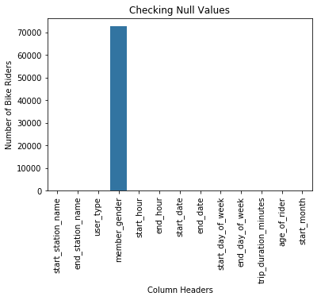

```python
#Visually check null values in columns
na_counts = bike_data_df.isna().sum()
base_color = sb.color_palette()[0]
sb.barplot(na_counts.index.values, na_counts, color = base_color)
plt.xticks(rotation=90)
plt.ylabel('Number of Bike Riders')
plt.xlabel('Column Headers')
plt.title('Checking Null Values')
```

```python
bike_data_df[bike_data_df['member_gender'].isnull()]
```

|  | start_station_name | end_station_name | user_type | member_gender | start_hour | end_hour | start_date | end_date | start_day_of_week | end_day_of_week | trip_duration_minutes | age_of_rider | start_month |
| --- | --- | --- | --- | --- | --- | --- | --- | --- | --- | --- | --- | --- | --- |
| 2 | Downtown Berkeley BART | Downtown Berkeley BART | Customer | NaN | 22 | 11 | 2017-12-31 | 2018-01-01 | Sunday | Sunday | 762.800000 | 0 | Dec |
| 3 | 8th St at Ringold St | Powell St BART Station (Market St at 5th St) | Customer | NaN | 17 | 10 | 2017-12-31 | 2018-01-01 | Sunday | Sunday | 1036.200000 | 0 | Dec |
| 5 | San Francisco Caltrain (Townsend St at 4th St) | San Francisco Caltrain (Townsend St at 4th St) | Customer | NaN | 22 | 1 | 2017-12-31 | 2018-01-01 | Sunday | Sunday | 153.766667 | 0 | Dec |
| 7 | Yerba Buena Center for the Arts (Howard St at ... | Yerba Buena Center for the Arts (Howard St at ... | Customer | NaN | 23 | 0 | 2017-12-31 | 2018-01-01 | Sunday | Sunday | 72.233333 | 0 | Dec |
| 8 | Mechanics Monument Plaza (Market St at Bush St) | Mechanics Monument Plaza (Market St at Bush St) | Customer | NaN | 23 | 0 | 2017-12-31 | 2018-01-01 | Sunday | Sunday | 69.166667 | 0 | Dec |
| 9 | Mechanics Monument Plaza (Market St at Bush St) | Mechanics Monument Plaza (Market St at Bush St) | Customer | NaN | 23 | 0 | 2017-12-31 | 2018-01-01 | Sunday | Sunday | 70.633333 | 0 | Dec |
| 10 | Yerba Buena Center for the Arts (Howard St at ... | Howard St at Beale St | Customer | NaN | 23 | 0 | 2017-12-31 | 2018-01-01 | Sunday | Sunday | 54.866667 | 0 | Dec |
| 11 | Yerba Buena Center for the Arts (Howard St at ... | Howard St at Beale St | Customer | NaN | 23 | 0 | 2017-12-31 | 2018-01-01 | Sunday | Sunday | 52.950000 | 0 | Dec |
| 14 | 3rd St at Townsend St | The Embarcadero at Steuart St | Customer | NaN | 23 | 0 | 2017-12-31 | 2018-01-01 | Sunday | Sunday | 44.950000 | 0 | Dec |
| 17 | Folsom St at 9th St | San Francisco Ferry Building (Harry Bridges Pl... | Customer | NaN | 23 | 0 | 2017-12-31 | 2018-01-01 | Sunday | Sunday | 23.283333 | 0 | Dec |
| 18 | Folsom St at 9th St | San Francisco Ferry Building (Harry Bridges Pl... | Subscriber | NaN | 23 | 0 | 2017-12-31 | 2018-01-01 | Sunday | Sunday | 25.533333 | 30 | Dec |
| 21 | San Francisco Caltrain (Townsend St at 4th St) | The Embarcadero at Sansome St | Customer | NaN | 22 | 0 | 2017-12-31 | 2018-01-01 | Sunday | Sunday | 69.566667 | 0 | Dec |
| 23 | 3rd St at Townsend St | The Embarcadero at Steuart St | Customer | NaN | 23 | 23 | 2017-12-31 | 2017-12-31 | Sunday | Sunday | 19.416667 | 0 | Dec |
| 24 | 3rd St at Townsend St | The Embarcadero at Steuart St | Customer | NaN | 23 | 23 | 2017-12-31 | 2017-12-31 | Sunday | Sunday | 19.150000 | 0 | Dec |
| 25 | 3rd St at Townsend St | The Embarcadero at Steuart St | Customer | NaN | 23 | 23 | 2017-12-31 | 2017-12-31 | Sunday | Sunday | 18.833333 | 0 | Dec |
| 26 | 3rd St at Townsend St | The Embarcadero at Steuart St | Customer | NaN | 23 | 23 | 2017-12-31 | 2017-12-31 | Sunday | Sunday | 16.716667 | 0 | Dec |
| 27 | The Embarcadero at Sansome St | San Francisco Ferry Building (Harry Bridges Pl... | Customer | NaN | 23 | 23 | 2017-12-31 | 2017-12-31 | Sunday | Sunday | 14.366667 | 0 | Dec |
| 29 | The Embarcadero at Sansome St | San Francisco Ferry Building (Harry Bridges Pl... | Customer | NaN | 23 | 23 | 2017-12-31 | 2017-12-31 | Sunday | Sunday | 13.066667 | 0 | Dec |
| 30 | The Embarcadero at Sansome St | San Francisco Ferry Building (Harry Bridges Pl... | Customer | NaN | 23 | 23 | 2017-12-31 | 2017-12-31 | Sunday | Sunday | 12.783333 | 0 | Dec |
| 31 | S Park St at 3rd St | Davis St at Jackson St | Customer | NaN | 22 | 23 | 2017-12-31 | 2017-12-31 | Sunday | Sunday | 86.550000 | 0 | Dec |
| 37 | San Francisco Caltrain (Townsend St at 4th St) | The Embarcadero at Sansome St | Customer | NaN | 22 | 23 | 2017-12-31 | 2017-12-31 | Sunday | Sunday | 41.850000 | 0 | Dec |
| 38 | San Francisco Caltrain (Townsend St at 4th St) | The Embarcadero at Sansome St | Customer | NaN | 22 | 23 | 2017-12-31 | 2017-12-31 | Sunday | Sunday | 48.266667 | 0 | Dec |
| 42 | Post St at Kearny St | Steuart St at Market St | Customer | NaN | 23 | 23 | 2017-12-31 | 2017-12-31 | Sunday | Sunday | 10.033333 | 0 | Dec |
| 43 | 3rd St at Townsend St | The Embarcadero at Steuart St | Customer | NaN | 23 | 23 | 2017-12-31 | 2017-12-31 | Sunday | Sunday | 21.150000 | 0 | Dec |
| 44 | 3rd St at Townsend St | The Embarcadero at Steuart St | Customer | NaN | 23 | 23 | 2017-12-31 | 2017-12-31 | Sunday | Sunday | 20.783333 | 0 | Dec |
| 45 | San Francisco City Hall (Polk St at Grove St) | The Embarcadero at Vallejo St | Customer | NaN | 22 | 23 | 2017-12-31 | 2017-12-31 | Sunday | Sunday | 88.166667 | 0 | Dec |
| 49 | The Embarcadero at Sansome St | The Embarcadero at Sansome St | Customer | NaN | 23 | 23 | 2017-12-31 | 2017-12-31 | Sunday | Sunday | 13.033333 | 0 | Dec |
| 50 | The Embarcadero at Sansome St | The Embarcadero at Sansome St | Customer | NaN | 23 | 23 | 2017-12-31 | 2017-12-31 | Sunday | Sunday | 13.316667 | 0 | Dec |
| 51 | The Embarcadero at Sansome St | The Embarcadero at Sansome St | Customer | NaN | 23 | 23 | 2017-12-31 | 2017-12-31 | Sunday | Sunday | 9.583333 | 0 | Dec |
| 53 | The Embarcadero at Vallejo St | Montgomery St BART Station (Market St at 2nd St) | Customer | NaN | 19 | 23 | 2017-12-31 | 2017-12-31 | Sunday | Sunday | 223.466667 | 0 | Dec |
| ... | ... | ... | ... | ... | ... | ... | ... | ... | ... | ... | ... | ... | ... |
| 519436 | 2nd St at Townsend St - Coming Soon | The Embarcadero at Vallejo St | Customer | NaN | 15 | 16 | 2017-06-28 | 2017-06-28 | Wednesday | Wednesday | 20.033333 | 0 | Jun |
| 519437 | 2nd St at Townsend St - Coming Soon | The Embarcadero at Vallejo St | Customer | NaN | 15 | 16 | 2017-06-28 | 2017-06-28 | Wednesday | Wednesday | 20.016667 | 0 | Jun |
| 519439 | 5th at Folsom | 5th at Folsom | Customer | NaN | 13 | 16 | 2017-06-28 | 2017-06-28 | Wednesday | Wednesday | 137.850000 | 0 | Jun |
| 519475 | The Embarcadero at Sansome St | The Embarcadero at Sansome St | Customer | NaN | 13 | 15 | 2017-06-28 | 2017-06-28 | Wednesday | Wednesday | 157.483333 | 0 | Jun |
| 519481 | The Embarcadero at Vallejo St | The Embarcadero at Sansome St | Customer | NaN | 15 | 15 | 2017-06-28 | 2017-06-28 | Wednesday | Wednesday | 12.666667 | 0 | Jun |
| 519483 | Howard St at Beale St | Powell St BART Station (Market St at 5th St) | Customer | NaN | 15 | 15 | 2017-06-28 | 2017-06-28 | Wednesday | Wednesday | 18.066667 | 0 | Jun |
| 519493 | The Embarcadero at Sansome St | The Embarcadero at Sansome St | Customer | NaN | 15 | 15 | 2017-06-28 | 2017-06-28 | Wednesday | Wednesday | 2.966667 | 0 | Jun |
| 519495 | Davis St at Jackson St | The Embarcadero at Sansome St | Customer | NaN | 15 | 15 | 2017-06-28 | 2017-06-28 | Wednesday | Wednesday | 11.500000 | 0 | Jun |
| 519497 | Davis St at Jackson St | The Embarcadero at Sansome St | Customer | NaN | 15 | 15 | 2017-06-28 | 2017-06-28 | Wednesday | Wednesday | 7.666667 | 0 | Jun |
| 519498 | The Embarcadero at Sansome St | The Embarcadero at Sansome St | Customer | NaN | 13 | 15 | 2017-06-28 | 2017-06-28 | Wednesday | Wednesday | 82.383333 | 0 | Jun |
| 519499 | The Embarcadero at Sansome St | The Embarcadero at Sansome St | Customer | NaN | 13 | 15 | 2017-06-28 | 2017-06-28 | Wednesday | Wednesday | 82.800000 | 0 | Jun |
| 519501 | Civic Center/UN Plaza BART Station (Market St ... | Civic Center/UN Plaza BART Station (Market St ... | Customer | NaN | 10 | 15 | 2017-06-28 | 2017-06-28 | Wednesday | Wednesday | 253.533333 | 0 | Jun |
| 519502 | Civic Center/UN Plaza BART Station (Market St ... | Civic Center/UN Plaza BART Station (Market St ... | Customer | NaN | 10 | 15 | 2017-06-28 | 2017-06-28 | Wednesday | Wednesday | 253.250000 | 0 | Jun |
| 519516 | San Francisco Ferry Building (Harry Bridges Pl... | Townsend St at 7th St | Customer | NaN | 14 | 14 | 2017-06-28 | 2017-06-28 | Wednesday | Wednesday | 20.800000 | 0 | Jun |
| 519541 | 2nd St at S Park St | San Francisco Ferry Building (Harry Bridges Pl... | Customer | NaN | 13 | 14 | 2017-06-28 | 2017-06-28 | Wednesday | Wednesday | 6.766667 | 0 | Jun |
| 519547 | Commercial St at Montgomery St | Montgomery St BART Station (Market St at 2nd St) | Customer | NaN | 13 | 13 | 2017-06-28 | 2017-06-28 | Wednesday | Wednesday | 5.000000 | 0 | Jun |
| 519552 | San Francisco Ferry Building (Harry Bridges Pl... | San Francisco Ferry Building (Harry Bridges Pl... | Customer | NaN | 13 | 13 | 2017-06-28 | 2017-06-28 | Wednesday | Wednesday | 26.000000 | 0 | Jun |
| 519573 | Market St at 10th St | The Embarcadero at Sansome St | Customer | NaN | 12 | 13 | 2017-06-28 | 2017-06-28 | Wednesday | Wednesday | 30.083333 | 0 | Jun |
| 519580 | The Embarcadero at Steuart St | 2nd St at Townsend St - Coming Soon | Customer | NaN | 12 | 13 | 2017-06-28 | 2017-06-28 | Wednesday | Wednesday | 11.116667 | 0 | Jun |
| 519581 | The Embarcadero at Steuart St | 2nd St at Townsend St - Coming Soon | Customer | NaN | 12 | 13 | 2017-06-28 | 2017-06-28 | Wednesday | Wednesday | 10.866667 | 0 | Jun |
| 519582 | The Embarcadero at Steuart St | 2nd St at Townsend St - Coming Soon | Customer | NaN | 12 | 13 | 2017-06-28 | 2017-06-28 | Wednesday | Wednesday | 10.983333 | 0 | Jun |
| 519583 | San Francisco City Hall (Polk St at Grove St) | Civic Center/UN Plaza BART Station (Market St ... | Customer | NaN | 12 | 13 | 2017-06-28 | 2017-06-28 | Wednesday | Wednesday | 8.666667 | 0 | Jun |
| 519601 | Montgomery St BART Station (Market St at 2nd St) | 2nd St at Townsend St - Coming Soon | Customer | NaN | 12 | 12 | 2017-06-28 | 2017-06-28 | Wednesday | Wednesday | 9.383333 | 0 | Jun |
| 519614 | Broadway at Battery St | 2nd St at Townsend St - Coming Soon | Customer | NaN | 11 | 12 | 2017-06-28 | 2017-06-28 | Wednesday | Wednesday | 14.350000 | 0 | Jun |
| 519616 | Bryant St at 6th St | 2nd St at S Park St | Customer | NaN | 12 | 12 | 2017-06-28 | 2017-06-28 | Wednesday | Wednesday | 6.050000 | 0 | Jun |
| 519631 | 2nd St at S Park St | 2nd St at S Park St | Customer | NaN | 10 | 11 | 2017-06-28 | 2017-06-28 | Wednesday | Wednesday | 63.650000 | 0 | Jun |
| 519639 | San Francisco City Hall (Polk St at Grove St) | The Embarcadero at Steuart St | Customer | NaN | 11 | 11 | 2017-06-28 | 2017-06-28 | Wednesday | Wednesday | 26.033333 | 0 | Jun |
| 519643 | San Francisco Ferry Building (Harry Bridges Pl... | San Francisco City Hall (Polk St at Grove St) | Customer | NaN | 10 | 11 | 2017-06-28 | 2017-06-28 | Wednesday | Wednesday | 29.633333 | 0 | Jun |
| 519663 | The Embarcadero at Bryant St | San Francisco City Hall (Polk St at Grove St) | Customer | NaN | 10 | 10 | 2017-06-28 | 2017-06-28 | Wednesday | Wednesday | 39.150000 | 0 | Jun |
| 519669 | Victoria Manalo Draves Park | The Embarcadero at Bryant St | Subscriber | NaN | 10 | 10 | 2017-06-28 | 2017-06-28 | Wednesday | Wednesday | 11.033333 | 38 | Jun |

72761 rows × 13 columns

```python
#drop null values from the dataset
bike_data_df.dropna(inplace=True)
```

```python
#drop duplicate values in dataframe
bike_data_df.drop_duplicates(inplace=True)
```

```python
bike_data_df.info()
```

```
<class 'pandas.core.frame.DataFrame'>
Int64Index: 446901 entries, 0 to 519699
Data columns (total 13 columns):
start_station_name       446901 non-null object
end_station_name         446901 non-null object
user_type                446901 non-null category
member_gender            446901 non-null category
start_hour               446901 non-null int64
end_hour                 446901 non-null int64
start_date               446901 non-null datetime64[ns]
end_date                 446901 non-null datetime64[ns]
start_day_of_week        446901 non-null category
end_day_of_week          446901 non-null category
trip_duration_minutes    446901 non-null float64
age_of_rider             446901 non-null int64
start_month              446901 non-null category
dtypes: category(5), datetime64[ns](2), float64(1), int64(3), object(2)
memory usage: 32.8+ MB
```

#### Grouping time of the day as -Early Morning; Morning Peak ; Afternoon ; Evening Peak ; Night

```python
bins = [0,7, 10,16,19,23]
labels = ['Early Morning','Morning Peak','Afternoon','Evening Peak','Night']
bike_data_df['time_of_the_day'] = pd.cut(bike_data_df['start_hour'], bins=bins, labels=labels,include_lowest=True)
```

### Exploratory Analysis - Univariate Exploration of Data

#### Question 1: How does the usage of bike rentals during each hour of the day varies?

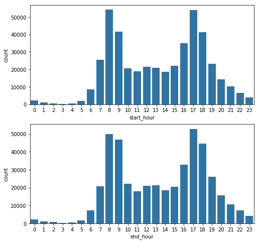

```python
fig, ax = plt.subplots(nrows=2, figsize = [8,8])

default_color = sb.color_palette()[0]
sb.countplot(data = bike_data_df, x = 'start_hour', color = default_color, ax = ax[0])

sb.countplot(data = bike_data_df, x = 'end_hour', color = default_color, ax = ax[1])

plt.show()
```

1. Group 1 : Early morning - 12 AM to 7 AM
2. Group 2 : Morning Peak - 7 AM to 10 AM.
3. Group 3: Aftenoon - 10 AM to 4 PM.
4. Group 4 Evening Peak - 4 PM to 7 PM.
5. Group 5 Night - 7 PM to 11 PM.

#### Question 2: Which age group uses the bike rentals the most?

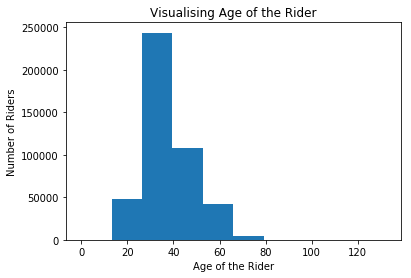

```python
plt.hist(data = bike_data_df, x = 'age_of_rider');
plt.xlabel('Age of the Rider')
plt.ylabel('Number of Riders')
plt.title('Visualising Age of the Rider');
```

#### The age group which uses the bike rentals most seems to be between 25-35. Also,Looks like there is outlier in the age . Hence, I am considering only those riders who are under the age of 90.

```python
bike_data_df = bike_data_df[bike_data_df['age_of_rider'] <= 90]
bike_data_df = bike_data_df[bike_data_df['age_of_rider'] >= 18]
```

```python
bike_data_df.info()
```

```
<class 'pandas.core.frame.DataFrame'>
Int64Index: 446419 entries, 0 to 519699
Data columns (total 14 columns):
start_station_name       446419 non-null object
end_station_name         446419 non-null object
user_type                446419 non-null category
member_gender            446419 non-null category
start_hour               446419 non-null int64
end_hour                 446419 non-null int64
start_date               446419 non-null datetime64[ns]
end_date                 446419 non-null datetime64[ns]
start_day_of_week        446419 non-null category
end_day_of_week          446419 non-null category
trip_duration_minutes    446419 non-null float64
age_of_rider             446419 non-null int64
start_month              446419 non-null category
time_of_the_day          446419 non-null category
dtypes: category(6), datetime64[ns](2), float64(1), int64(3), object(2)
memory usage: 33.2+ MB
```

#### Question 3 : What is the number of customers versus subscibers in the dataset?

```
Text(0.5,1,'Number of Customers vs Subscribers')
```

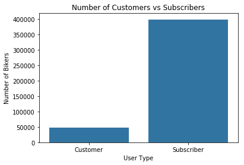

```python
base_color = sb.color_palette()[0]

sb.countplot(data=bike_data_df,x='user_type',color=base_color)
plt.xlabel('User Type')
plt.ylabel('Number of Bikers')
plt.title('Number of Customers vs Subscribers')
```

#### The above graph shows the comparison between number of Customers versus number of Subscribers of Ford Bike Data.We can clearly see from the graph that here are more subscribers than customers for the dataset we have.

#### Question 4: What is the number of females versus males in the dataset?

```
Text(0.5,1,'Number of Males vs Females')
```

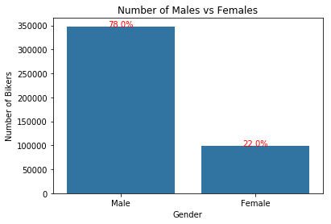

```python
# create the plot
base_color = sb.color_palette()[0]
sb.countplot(data = bike_data_df, x = 'member_gender', color = base_color)

# add annotations
n_points = bike_data_df.shape[0]
cat_counts = bike_data_df['member_gender'].value_counts()
locs, labels = plt.xticks() # get the current tick locations and labels

# loop through each pair of locations and labels
for loc, label in zip(locs, labels):

    # get the text property for the label to get the correct count
    count = cat_counts[label.get_text()]
    pct_string = '{:0.1f}%'.format(100*count/n_points)

    # print the annotation just below the top of the bar
    plt.text(loc, count-8, pct_string, ha = 'center', color = 'r')

plt.xlabel('Gender')
plt.ylabel('Number of Bikers')
plt.title('Number of Males vs Females')
```

##### The above graph shows the comparison between number of bikes rented by Males versus number of number of bike rented by Female of Ford Bike Data. We have more males than females in the dataset with 78% Males and 22% Females.

#### Question 4: What is the bike usage during each day of the week?

```
Text(0.5,1,'Number of Bikers during each Day of Week')
```

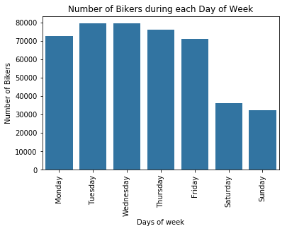

```python
level_order = ['Monday', 'Tuesday', 'Wednesday','Thursday','Friday','Saturday','Sunday']
ordered_cat = pd.api.types.CategoricalDtype(ordered = True, categories = level_order)
bike_data_df['start_day_of_week'] = bike_data_df['start_day_of_week'].astype(ordered_cat)

base_color = sb.color_palette()[0]

sb.countplot(data=bike_data_df,x='start_day_of_week',color=base_color)
plt.xticks(rotation = 90);

plt.xlabel('Days of week')
plt.ylabel('Number of Bikers')
plt.title('Number of Bikers during each Day of Week')
```

#### The above graph is show the bike usage on weekdays as well as weekends. This graph shows that highest number of bikes are used on Tuesday and Wednesday.

#### Question 5 : Which are the top 10 busy stations for bike pickup?

```
Text(0.5,1,'Top 10 busy stations')
```

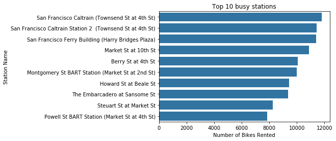

```python
base_color = sb.color_palette()[0]
start_station_name = bike_data_df['start_station_name'].value_counts()[:10].index
sb.countplot(data = bike_data_df, y = 'start_station_name', color = base_color, order = start_station_name)
plt.xlabel('Number of Bikes Rented')
plt.ylabel('Station Name')
plt.title('Top 10 busy stations')
```

### Bivariate Exploration - Bike Usage based on Weekday and Gender.

#### Question 6: What is the bike usage during each day of the week by each gender?

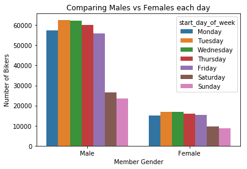

```python
sb.countplot(data = bike_data_df, x = 'member_gender', hue = 'start_day_of_week')
plt.xlabel('Member Gender')
plt.ylabel('Number of Bikers')
plt.title('Comparing Males vs Females each day');
```

##### The above graph analysis shows there are more number of male bike riders than the female bike riders and also number of bikes are used more on a weekday than on a weekend.

#### Question 7: What is the bike usage during each month of the year by each gender?

```
Text(0.5,1,'Comparing Males and Females during each Month')
```

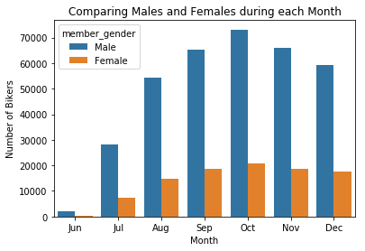

```python
level_order = ['Jun','Jul','Aug','Sep','Oct','Nov','Dec']


sb.countplot(data = bike_data_df, hue = 'member_gender', x = 'start_month',order=level_order)
plt.xlabel('Month')
plt.ylabel('Number of Bikers')
plt.title('Comparing Males and Females during each Month')
```

##### The above graph shows that most busiest month seems to be October and June is the least busiest for both male and female riders. Also, we can see that in each month there were more males renting a bike than females.

#### Correlation Plot between Numeric Variables

```python
numeric_vars = ['trip_duration_minutes','start_hour','age_of_rider']
```

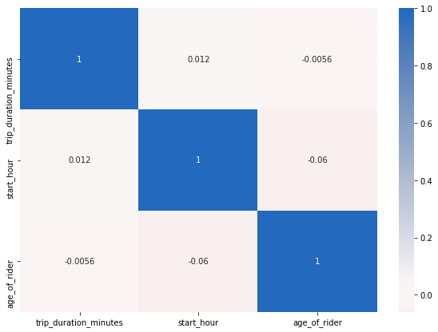

```python
# correlation plot
plt.figure(figsize = [10, 7])
sb.heatmap(bike_data_df[numeric_vars].corr(), annot = True,
           cmap = 'vlag_r', center = 0)
plt.show()
```

#### Quetsion 8: How is the Number of male or female customers and subscribers related?

```
Text(0.5,1,'Comparing Males and Females with User Type')
```

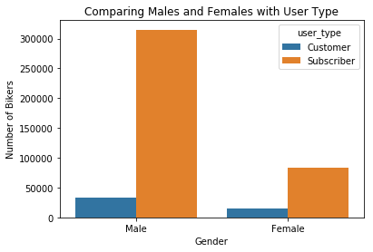

```python
sb.countplot(data = bike_data_df, x = 'member_gender', hue = 'user_type')
plt.xlabel('Gender')
plt.ylabel('Number of Bikers')
plt.title('Comparing Males and Females with User Type')
```

##### There are more subscribers for both the genders in comparison with customers. Also, we can see that male count is more than the female count.

#### Question 9: How is Bike usage by time of the day during each day of the week varies?

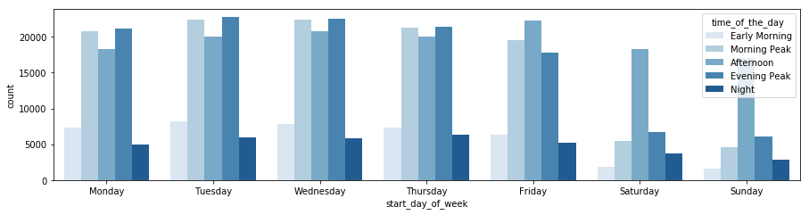

```python
plt.figure(figsize = [15, 12])

# subplot 1: color vs cut
plt.subplot(3, 1, 1)
sb.countplot(data = bike_data_df, x = 'start_day_of_week', hue = 'time_of_the_day', palette = 'Blues')

plt.show()
```

##### The above graph clearly shows that weekdays are more busy than weekends and graph shows the peak hours of the day.

#### Box Plot showing age of rider on weekday.

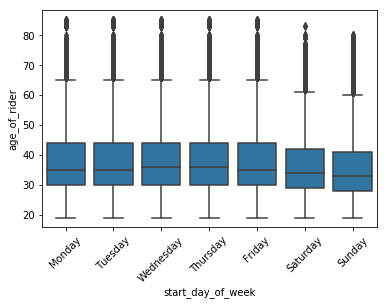

```python
base_color = sb.color_palette()[0]

sb.boxplot(data = bike_data_df, x = 'start_day_of_week', y = 'age_of_rider',color=base_color)
plt.xticks(rotation=45);
```

### Multivariate Exploration of Data

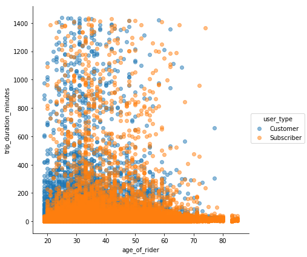

```python
g = sb.FacetGrid(data = bike_data_df, hue = 'user_type', size = 6)
g.map(plt.scatter, 'age_of_rider','trip_duration_minutes',alpha=0.5)
y_ticks = [400, 800,1200, 1600, 2000, 2400]
x_ticks = [20,30,40,50,60,70,80]
g.add_legend()
```

#### Multivariate graph between time of day, gender and age of the rider

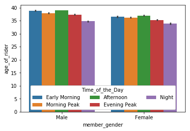

```python
ax = sb.barplot(data = bike_data_df, x = 'member_gender', y = 'age_of_rider', hue = 'time_of_the_day')
ax.legend(loc =8, ncol = 3, framealpha = 1, title = 'Time_of_the_Day')
```

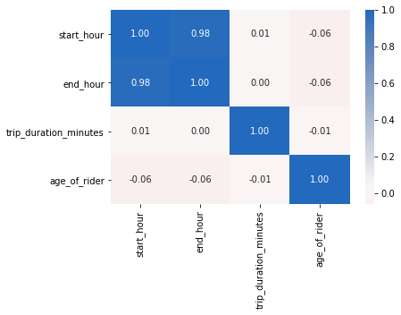

```python
sb.heatmap(bike_data_df.corr(), annot = True, fmt = '.2f', cmap = 'vlag_r', center = 0)
```

```python
from subprocess import call
call(['python', '-m', 'nbconvert', 'exploration_template.ipynb'])
```

```
0
```

## Insights:

#### Population consisted mostly of male riders(78%) than female riders(22%). We observed that there are more subscribers in the dataset than customers. The most common age group who rides the bike is between 25-35. We can clearly see that the morning peak(7 am to 10 am) and evening peak (4 pm to 7 pm) data is the busiest hours of day in the data provided. We also observed that weekdays are more busy than the weekends and hence assumed that mostly bikes are rented by people for commute to and from work.

#### One of the graphs also suggested us that the busiest month from June to December is October.

### Summing up the observations- There are more subscribers and are mostly males who ride bikes more on weekdays than on weekends during the morning peak and evening peak hours in the month of October.